# MA334-SP-Individual Assignment 2023

Biodiversity Proportional Species Richness

2211553

## INTRODUCTION:

All living things on earth, as well as the ecosystems in which they coexist, are referred to as part of the biodiversity of the planet. It includes the genetic diversity within species, the diversity of ecosystems, and the ecological processes that support life. It also includes the diversity of species.

A variety of legal and policy tools have been used in the United Kingdom to take action to preserve biodiversity. The Wildlife and Countryside Act of 1981, which offers legal protection for numerous species and ecosystems, is one of the most crucial. A Biodiversity Action Plan, created by the UK government in 1994, describes methods for protecting biodiversity among various habitats and species.

Here, we use proportional_species_richness.csv to analyse species data, for data analysis and statistical analysis of biodiversity across Great Britain. These data represent a valuable resource for diversity of ecosystems based on ecological species value. We analyze species count and mean patterns of this data and apply the statistical analysis to consider the ecological status of species on land zones in Great Britain.

## METHODS:

1.**Data Collection**

2.**Sampling Methods**

3.**Statistical techniques in Analysis**

Sample data used for analysis:

|  | Bees | Bird | Bryophytes | Butterflies | Hoverflies | Macromoths | Grasshoppers_._Crickets | Easting | Northing | dominantLandClass | ecologicalStatus | period | ecostatusof7 |
| --- | --- | --- | --- | --- | --- | --- | --- | --- | --- | --- | --- | --- | --- |
| 1 | 0.07526882 | 0.5968200 | 0.6445703 | 0.6444444 | 0.2871126 | 0.3154528 | 0.2500000 | 450000 | 1200000 | 32s | 0.4292174 | Y70 | 0.4019527 |
| 2 | 0.08602150 | 0.6044203 | 0.6479014 | 0.4611111 | 0.2903752 | 0.3494094 | 0.2500000 | 460000 | 1200000 | 32s | 0.4178607 | Y70 | 0.3841770 |
| 3 | 0.07526882 | 0.5931485 | 0.6429047 | 0.6222222 | 0.3017945 | 0.3533465 | 0.2500000 | 460000 | 1210000 | 32s | 0.4277593 | Y70 | 0.4055264 |
| 4 | 0.21875000 | 0.5741327 | 0.6751838 | 0.5080214 | 0.4070981 | 0.4018110 | 0.1666667 | 420000 | 1140000 | 31s | 0.4663815 | Y70 | 0.4216662 |

## RESULTS:

## **DATA EXPLORATION:**

1.The below graph presents the mean difference, in the species richness compared to different time period between `BD7` and `BD11`. Thus, by the clear graphical presentation we can say, count of `BD11` and `BD7` has increased in the period “Y00” than “Y70”.

This shows that there could have been measures taken to improve richness during the period “Y70” and could have resulted in the future, thus shows the difference. But in both the time period their is a sudden spike and it has been depleted, this presentation could mean there is a shortage of data which could not give more accurate analysis.

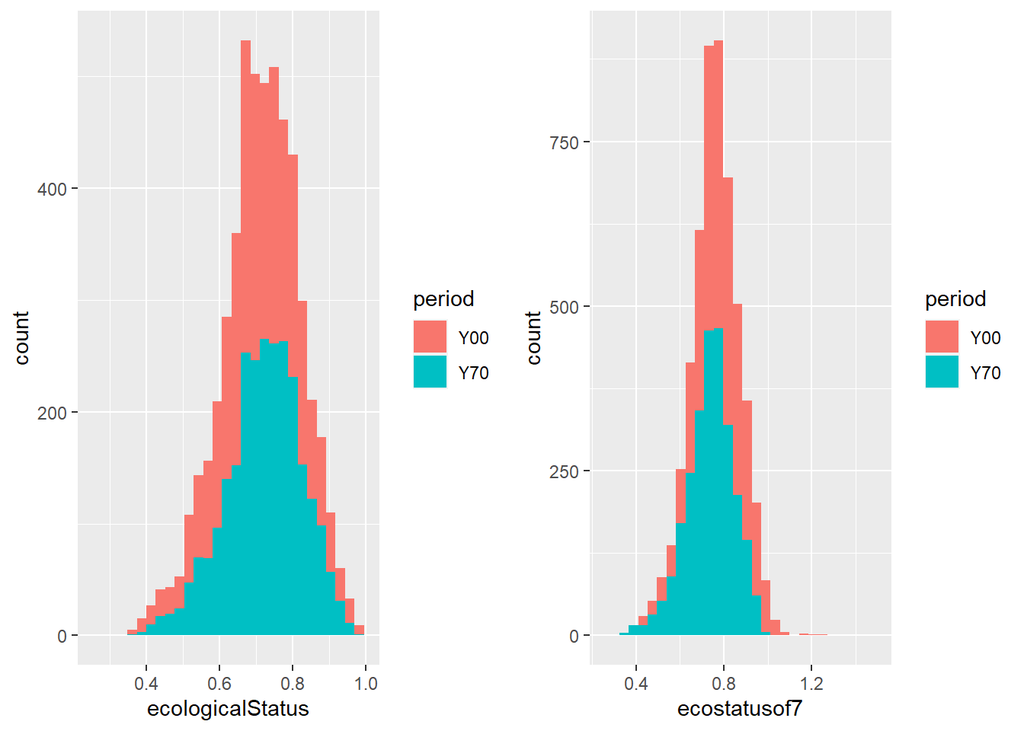

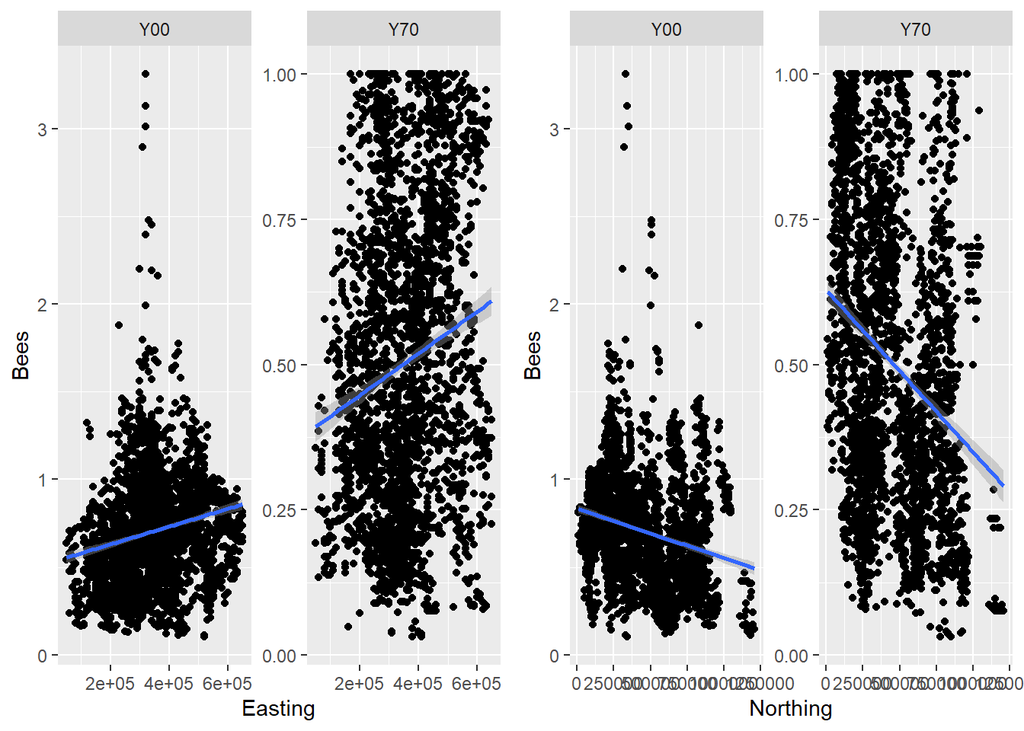

## **Hypothesis Testing:**

1. For all land zone in Scotland, it has shown increase in mean of ecological score of 7 species.
- Null hypothesis: Ecological score in Scotland has not increased over time.
- Alternative hypothesis: Ecological score in Scotland has increased over time.

The level of significance taken is 0.95

```
##
##  One Sample t-test
##
## data:  dff_in_eco_score_scotland$period_dff
## t = 3.8219, df = 15, p-value = 0.0008335
## alternative hypothesis: true mean is greater than 0
## 95 percent confidence interval:
##  0.01506418        Inf
## sample estimates:
##  mean of x
## 0.02782915
```

Conclusion:  
As the p-value is < 0.05, we reject the Null-Hypothesis thus proving that the ecological species richness has increased in Scotland over time.

2. The BD7 for each `dominantlandclass` has increased over time from Y70 to Y00:
- Null hypothesis: BD7 for each `dominatlandclass` has not increased over time.
- Alternative hypothesis: BD7 for each `dominatlandclass` has increased over time.

The level of significance taken is 0.99

```
##
##  One Sample t-test
##
## data:  best_eco_Y00$period_dff
## t = 8.0547, df = 44, p-value = 1.684e-10
## alternative hypothesis: true mean is greater than 0
## 99 percent confidence interval:
##  0.0289111       Inf
## sample estimates:
##  mean of x
## 0.04128494
```

Conclusion:

## **Simple linear regression**

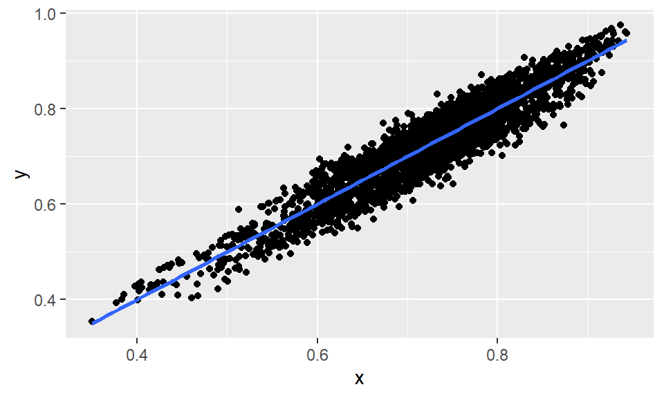

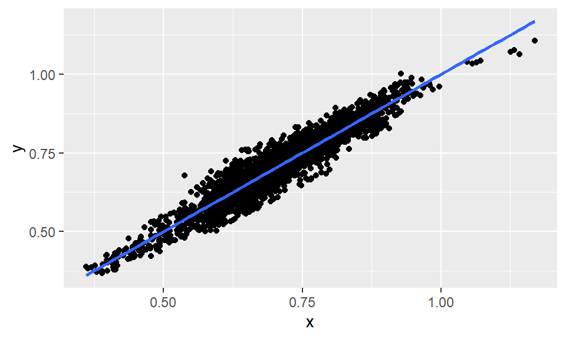

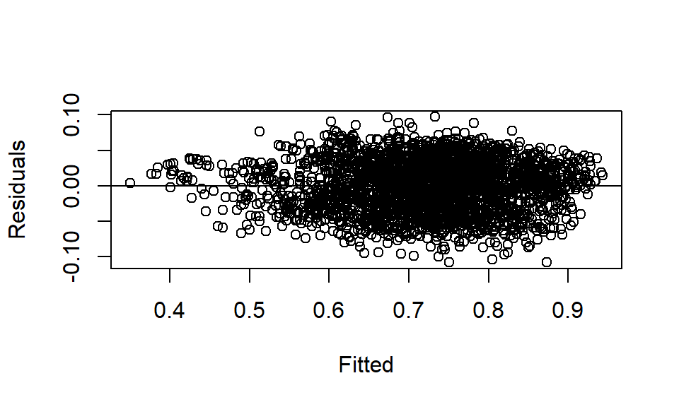

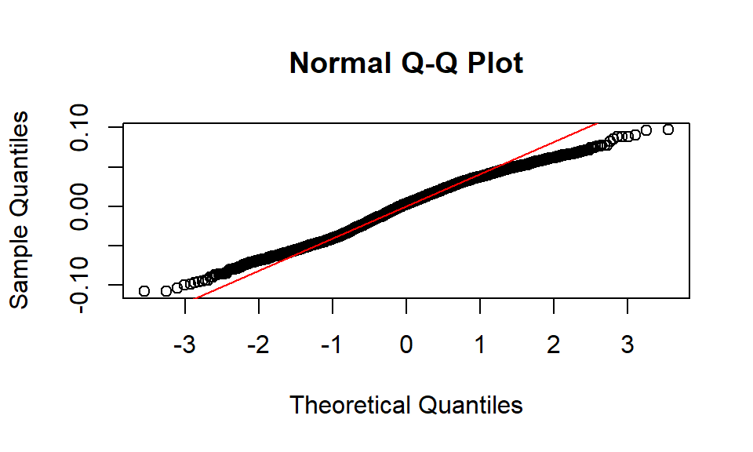

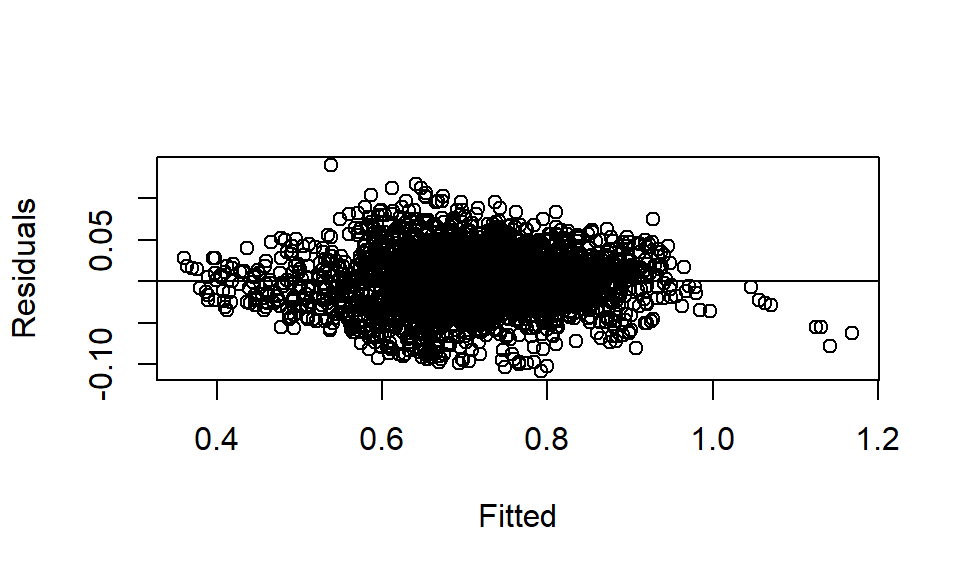

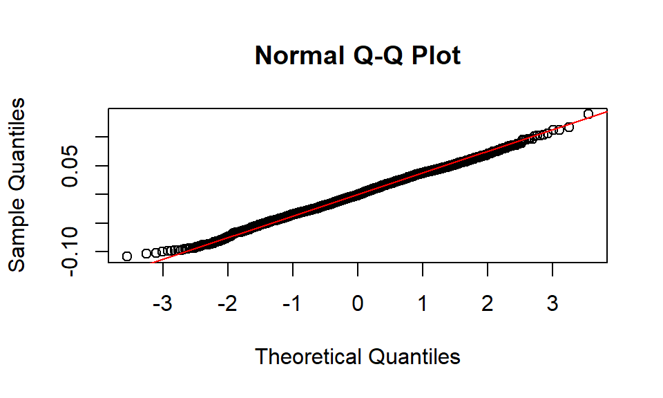

## **Multiple linear regression**

The objective of this section is to predict the value of `BD4`(mean ecological score of the remaining 4 species) using different combinations of the seven allocated species. From the below graph and the results returned by AIC it is observed that the model which takes all seven species as its predictors does an efficient prediction out of all the models run.

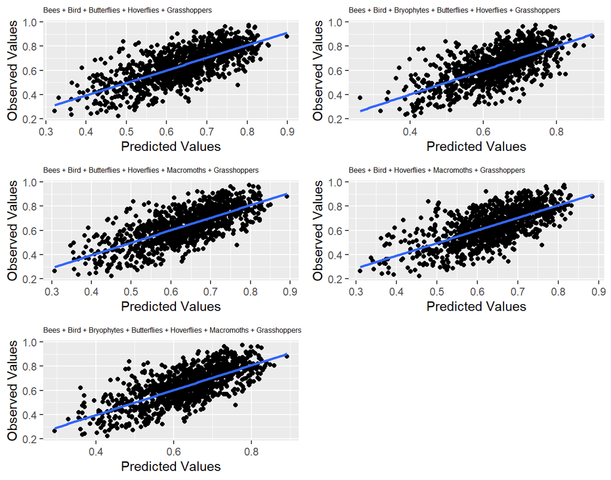

|  | df | AIC |
| --- | --- | --- |
| mlr_proj1 | 9 | -7445.946 |
| species_proj1 | 7 | -7315.830 |
| species_proj2 | 7 | -7047.517 |
| species_proj3 | 8 | -7371.590 |
| species_proj4 | 7 | -6848.514 |

## **Open analysis**

In this section, we analyse the proportional contribution of the highly correlated species to the mean species richness value(BD7) in all land zones for both time periods across all 3 countries(England, Scotland, Wales).

#### **England**

From the below graph, it is seen that the correlation between the species tends be on par on both the time period, expect for bees where it shows an increase over time.

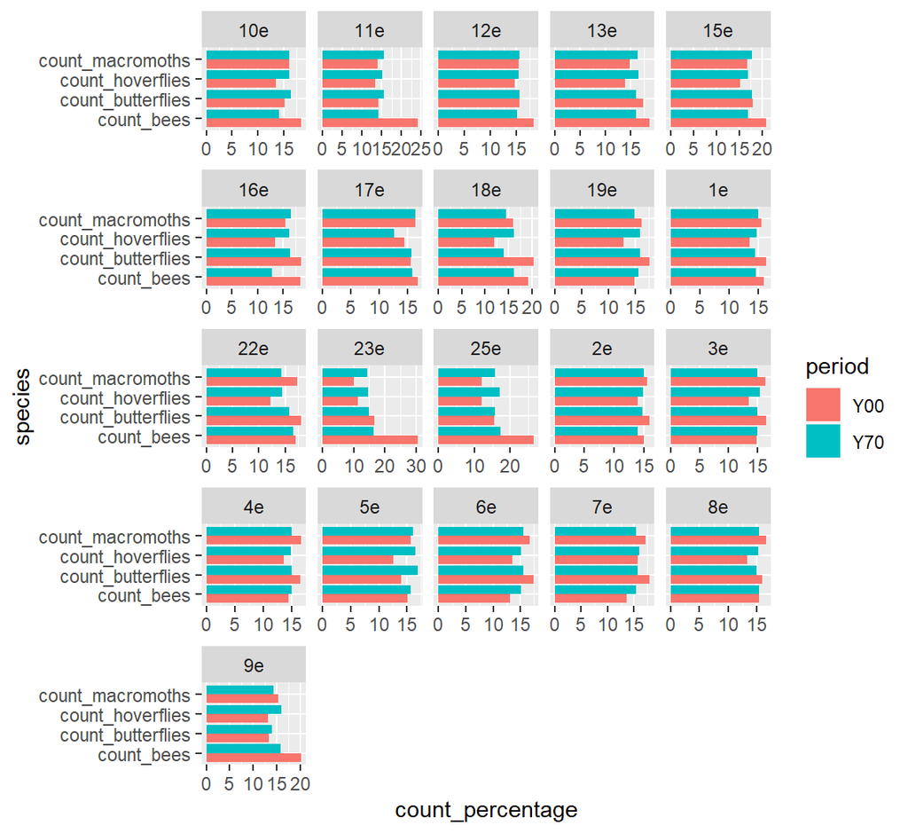

#### **Scotland**

In this graph it is noted that the butterflies and bees tends to have a high indication from rest of the species. But still bees show more richness than butterflies.

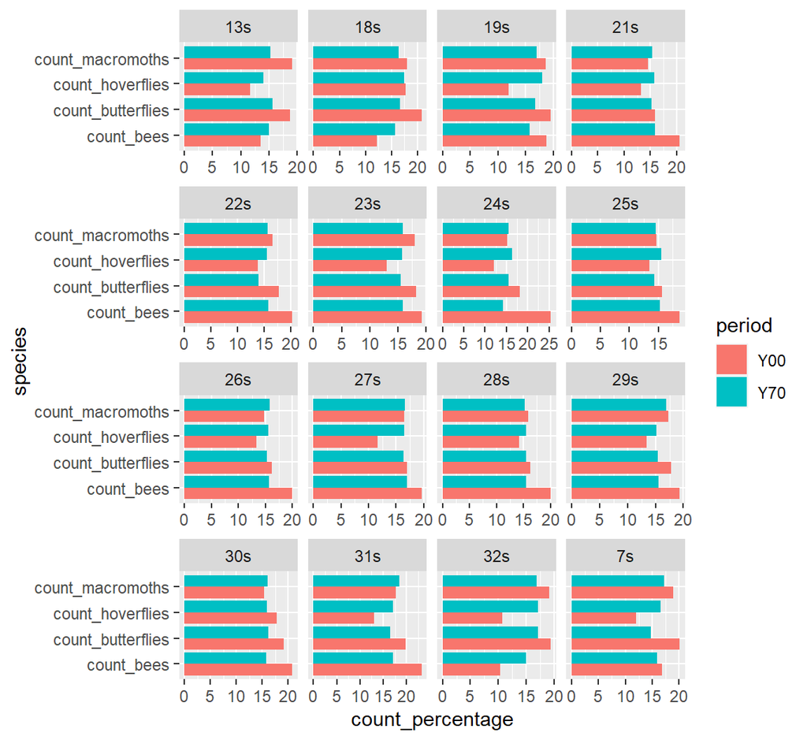

#### **Wales**

From the below plot, it is observed that in some land zones the bees have increased in the `Y00` period but have stayed on par with the other species across both time period.

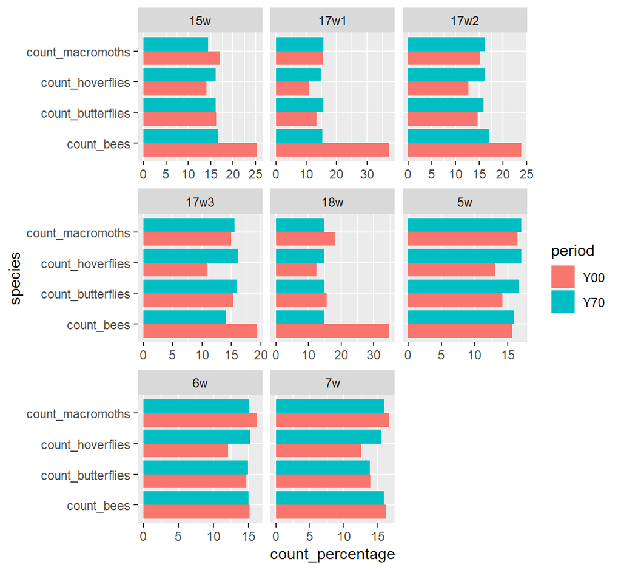